# Efekty przestrzenne

Przemyslaw Biecek

Modele liniowe z efektami stałymi i mieszanymi

# 1. Ceny mieszkań

Będziemy pracować z cenami mieszkań pobranymi z serwisu `http://www.oferty.net/`. Zawiera ceny mieszkań z okresu 2007-2009.

```r
library(lme4)
library(PBImisc)
library(ggplot2)

head(apartments <- na.omit(apartments[,c(1,5,9, 13,15,16)]))
```

```
##   year    district construction.date m2.price      lat      lon
## 1 2008 Srodmiescie              1970    10500 52.22947 21.00761
## 2 2008    Pruszkow              1965     7000 52.17162 20.80639
## 3 2008     Bielany              1964     8384 52.27114 20.95003
## 4 2008        Wola              1962     8518 52.24238 20.98659
## 5 2008     Mokotow              1950     8750 52.19814 21.01752
## 6 2008     Mokotow              1968     8750 52.19814 21.01752
```

# 2. Regresja segmentowa

Jaka jest zależność pomiędzy wiekiem apartamentu a ceną metra kwadratowego?

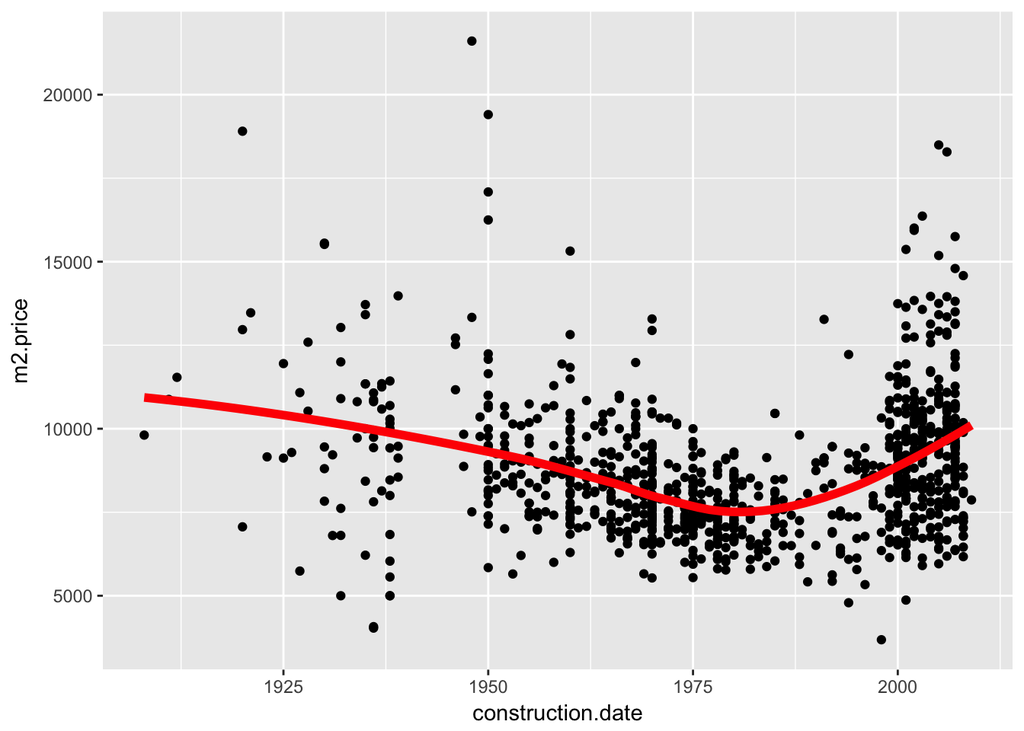

```r
ggplot(apartments, aes(construction.date, m2.price)) +
  geom_point() +
  geom_smooth(se=FALSE, color="red", size=2)
```

Czy ta zależność jest zaskakująca? Dlaczego nie jest monotoniczna?

.

.

.

Jak ją modelować?

Nie wygląda jak wielomian.

.

.

.

Jednym z rozwiązań jest regresja segmentowa. Pomysł jest taki: przybliżyć zależność za pomocą łamanej - kilku prostych odcinków.

Przykładowo, załóżmy, że zależność pomiędzy rokiem budowy mieszkania a ceną. Aby uprościć dalsze wnioskowanie załóżmy, że punktem zmiany jest rok 1990 (osobnym zagadnieniem jest jak taki punkt zmiany identyfikować).

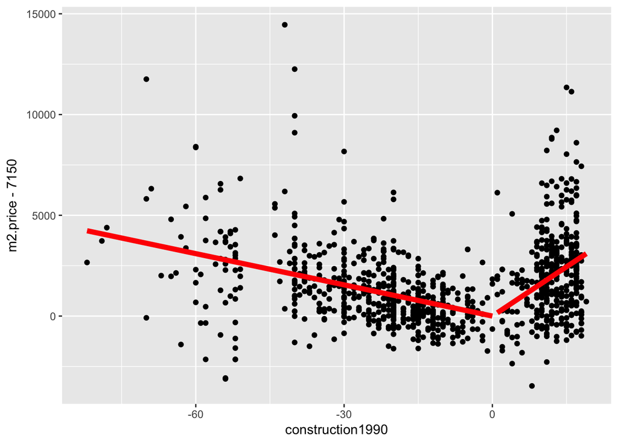

```r
apartments$construction1990 = apartments$construction.date - 1990
apartments$olderThan1990 = apartments$construction.date > 1990

model <- lm(m2.price ~ construction1990:olderThan1990, data=apartments)

model <- lm(m2.price ~ construction1990+construction1990:olderThan1990, data=apartments)

ggplot(apartments, aes(construction1990, m2.price-7150, group=olderThan1990)) +
  geom_point() +
  geom_smooth(se=FALSE, color="red", size=2, method="lm", formula=y~x-1)
```

Pytania.

1. Jak sprawdzić czy ta zależność opisywana jest za pomocą dwóch prostych? Może wystarczy jedna a może trzy?
2. Jak znaleźć optymalny punkt podziału?

.

.

.

# 3. Dane przestrzenne

Kolejną interesującą zmienną jest dzielnica. Czy mieszkania w różnych dzielnicach mają różne ceny? Z pewnością. Ale jak to modelować?

Zobaczmy kilka możliwych podejść.

Sensownym założeniem jest, że cena zależy jakoś od odległości do centrum, im bliżej tym drożej. Sensownie też założyć, że (przy założeniu stałości innych czynników) mieszkania blisko mają podobne ceny.

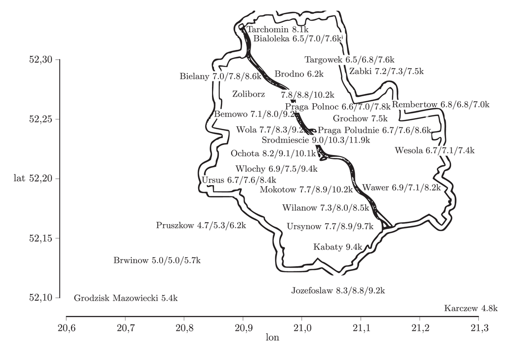

Aby zweryfikować tą hipotezę przekształćmy współrzędne geograficzne na odległość od centrum.

```r
# This function calculates distance between two points.
# It's an approximation but quite accurate within Warsaw
getDistKm <- function(x, y) {
 sqrt(sum(((x-y)*c(100,70))^2))
}

# where is the downtown?
head(apartmentsInDownTown <- which(apartments$district == "Srodmiescie"))
```

```
## [1]  1  7  9 25 26 42
```

```r
(downTownCoords = apartments[apartmentsInDownTown[1],5:6])
```

```
##        lat      lon
## 1 52.22947 21.00761
```

```r
# how far is the city centre?
# for each district, how far it is from down town
districts <- levels(apartments$district)
distances <- sapply(districts, function(x)
  getDistKm(downTownCoords, apartments[apartments$district == x, 5:6][1,]))

head(distances)
```

```
##    Bemowo Bialoleka   Bielany    Brodno   Brwinow   Grochow
##  6.354417  8.903394  5.797603  6.246869 21.861944  6.785008
```

Zobaczmy jak wygląda rozkład ceny jako funkcja odległości od centrum.

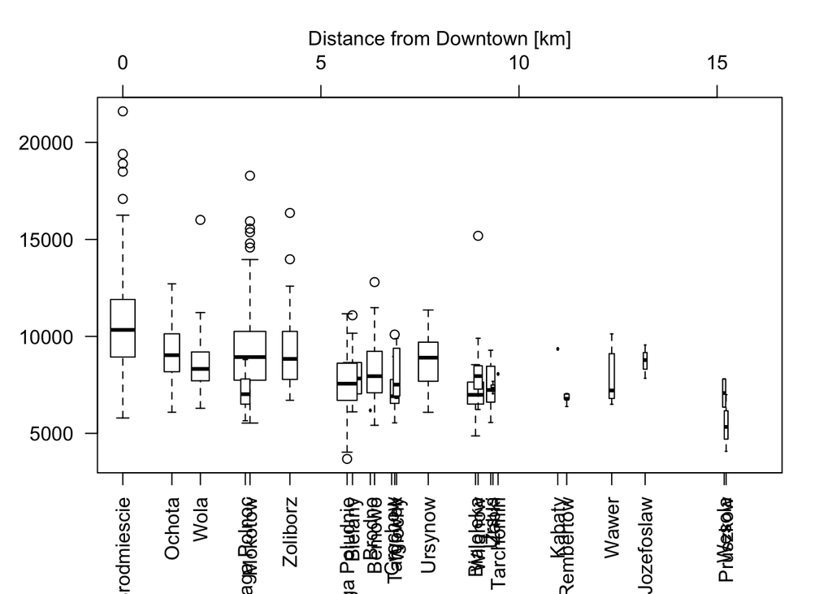

```r
boxplot(m2.price~district, data=apartments, at=distances, varwidth=TRUE, bty="n", las=2, xlim=c(0,16))
axis(3); mtext("Distance from Downtown [km]", line=2)
```

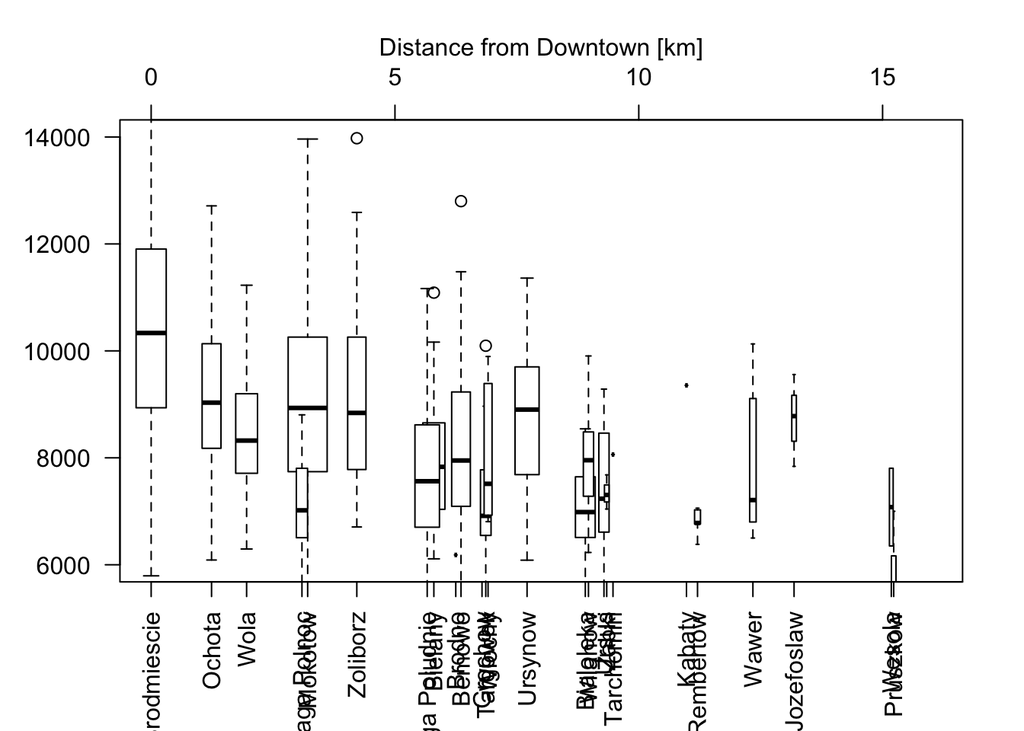

```r
boxplot(m2.price~district, data=apartments, at=distances, varwidth=TRUE, bty="n", las=2, xlim=c(0,16), ylim=c(6000,14000))
axis(3); mtext("Distance from Downtown [km]", line=2)
```

Jak sprawdzić czy taka zależność jest istotna?

```r
# add information about distances to data frame
apartments$distances = distances[apartments$district]
# add this variable to the model
summary(model2 <- update(model, .~. + distances))
```

```
##
## Call:
## lm(formula = m2.price ~ construction1990 + distances + construction1990:olderThan1990,
##     data = apartments)
##
## Residuals:
##     Min      1Q  Median      3Q     Max
## -4842.0 -1000.6  -171.3   840.7 11497.8
##
## Coefficients:
##                                    Estimate Std. Error t value Pr(>|t|)
## (Intercept)                        8661.591    150.017  57.737  < 2e-16
## construction1990                    -34.418      4.283  -8.037  2.7e-15
## distances                          -290.796     17.398 -16.714  < 2e-16
## construction1990:olderThan1990TRUE  211.937     14.033  15.103  < 2e-16
##
## (Intercept)                        ***
## construction1990                   ***
## distances                          ***
## construction1990:olderThan1990TRUE ***
## ---
## Signif. codes:  0 '***' 0.001 '**' 0.01 '*' 0.05 '.' 0.1 ' ' 1
##
## Residual standard error: 1666 on 960 degrees of freedom
## Multiple R-squared:  0.3487, Adjusted R-squared:  0.3467
## F-statistic: 171.3 on 3 and 960 DF,  p-value: < 2.2e-16
```

To jedno podejście, a jakie inne opcje mamy?

.

.

.

Czy ważna jest jedynie odległość od centrum?

A może problemem jest Wisła i liczy się głównie odległość wschód-zachód?

Jak sprawdzić która odległość jest lepsza?

.

.

.

Jednym z przydatnych narzędzi może być wariogram. Pomaga on oszacować jak bliskość geograficzna koreluje z bliskością ceny.

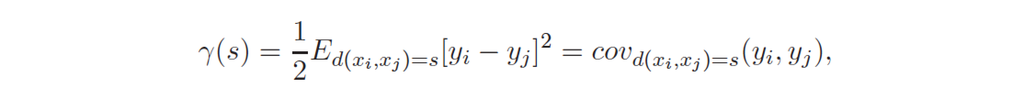

Naturalnym estymatorem (na regularnej kracie) jest.

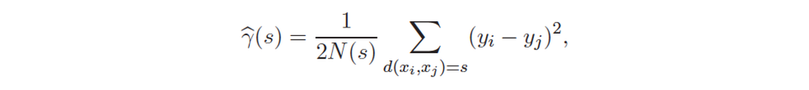

Jeżeli obserwacje nie są na regularnej kracie zazwyczaj stosuje się jakieś wygładzanie.

Zobaczmy dwa przykładowe wariogramy, dla odległości od centrum i dla odległości w kierunku wschód - zachód.

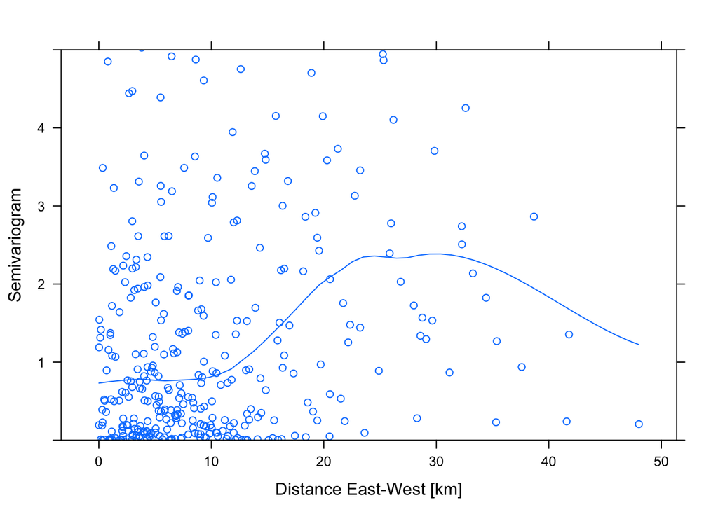

```r
avg.m2.price = tapply(apartments$m2.price, apartments$district, mean) / 1000
lon <- tapply(apartments$lon, apartments$district, mean) * 70
lat <- tapply(apartments$lat, apartments$district, mean) * 100
districts.aggr = data.frame(avg.m2.price, lon, lat)
# the Variogram() function calculates a variogram
library(nlme)
plot(Variogram(districts.aggr$avg.m2.price, dist(districts.aggr$lon)),
  xlab="Distance East-West [km]", span=0.4, ylim = c(0,5))
```

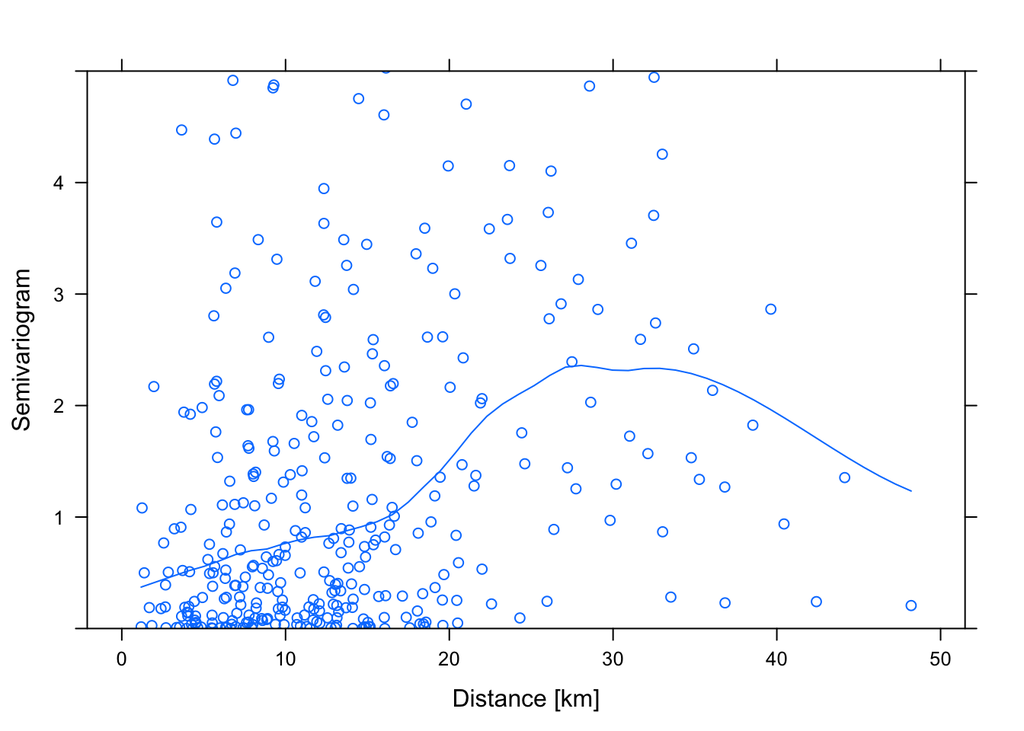

```r
plot(Variogram(districts.aggr$avg.m2.price, dist(districts.aggr[,2:3])),
  xlab="Distance [km]", span=0.4, ylim = c(0,5))
```

[Variograms in other packages](http://www.ats.ucla.edu/stat/r/faq/variogram.htm)

Co się dzieje dla bardzo małych i bardzo dużych odległości?

.

.

.

Wykresy są ładne dla oka, ale jak to testować?

Jednym z podejść jest test Mantela dla korelacji dwóch macierzy odległości/podobieństwa.

Jako statystyka testowa używany jest współczynnik Pearsona, a rozkład tej statystyki jest znajdowany za pomocą permutacji.

```r
library(ade4)
distSpatial <- dist(districts.aggr[,2:3])
as.matrix(distSpatial)[1:5,1:5]
```

```
##              Bemowo Bialoleka   Bielany    Brodno  Brwinow
## Bemowo     0.000000  9.232075  1.835921  7.627969 18.50165
## Bialoleka  9.232075  0.000000  7.398314  2.672031 27.73335
## Bielany    1.835921  7.398314  0.000000  5.845888 20.33670
## Brodno     7.627969  2.672031  5.845888  0.000000 25.96880
## Brwinow   18.501655 27.733352 20.336702 25.968801  0.00000
```

```r
distPrice <- dist(districts.aggr$avg.m2.price)
as.matrix(distPrice)[1:5,1:5]
```

```
##              Bemowo Bialoleka   Bielany    Brodno   Brwinow
## Bemowo    0.0000000 1.0965486 0.2294771 1.9811200 2.6797867
## Bialoleka 1.0965486 0.0000000 0.8670714 0.8845714 1.5832381
## Bielany   0.2294771 0.8670714 0.0000000 1.7516429 2.4503095
## Brodno    1.9811200 0.8845714 1.7516429 0.0000000 0.6986667
## Brwinow   2.6797867 1.5832381 2.4503095 0.6986667 0.0000000
```

```r
mantel.rtest(distSpatial, distPrice, nrepet = 9999)
```

```
## Monte-Carlo test
## Call: mantel.rtest(m1 = distSpatial, m2 = distPrice, nrepet = 9999)
##
## Observation: 0.3973285
##
## Based on 9999 replicates
## Simulated p-value: 0.0017
## Alternative hypothesis: greater
##
##      Std.Obs  Expectation     Variance
##  3.467208201 -0.000348404  0.013155302
```

Wszystkie metody potwierdzają, że składowa przestrzenna jest istotna.

Ale jak ją modelować?

.

Użyjemy funkcji `lme()` z pakiety `nlme`, to poprzednik `lme4`, wolniejszy ale pozawala na bogatsze modelowanie zależności pomiędzy zmiennymi.

.

Macierz odległości dodamy do modelu wprost, jako składową opisującą strukturę korelacji dla efektów losowych.

Składowa przestrzenna w elemencie epsilon.

```r
apartments$dummy <- 1
apartments$lat <- apartments$lat + runif(length(apartments$lat),0,0.001)
apartments$lon <- apartments$lon + runif(length(apartments$lat),0,0.001)

model3 <- lme(m2.price ~ construction1990 + distances + construction1990:olderThan1990, correlation = corGaus(form = ~ lon+lat), apartments, random= ~1|dummy)

# summary
summary(model3)
```

```
## Linear mixed-effects model fit by REML
##  Data: apartments
##        AIC      BIC    logLik
##   17018.62 17052.69 -8502.312
##
## Random effects:
##  Formula: ~1 | dummy
##         (Intercept) Residual
## StdDev:    142.9979 1664.985
##
## Correlation Structure: Gaussian spatial correlation
##  Formula: ~lon + lat | dummy
##  Parameter estimate(s):
##        range
## 5.138388e-06
## Fixed effects: m2.price ~ construction1990 + distances + construction1990:olderThan1990
##                                       Value Std.Error  DF   t-value
## (Intercept)                        8656.703 207.17971 960  41.78355
## construction1990                    -34.451   4.27909 960  -8.05111
## distances                          -289.621  17.39371 960 -16.65091
## construction1990:olderThan1990TRUE  211.420  14.03546 960  15.06326
##                                    p-value
## (Intercept)                              0
## construction1990                         0
## distances                                0
## construction1990:olderThan1990TRUE       0
##  Correlation:
##                                    (Intr) cn1990 dstncs
## construction1990                    0.569
## distances                          -0.437 -0.240
## construction1990:olderThan1990TRUE -0.506 -0.792  0.012
##
## Standardized Within-Group Residuals:
##        Min         Q1        Med         Q3        Max
## -2.9102680 -0.5987545 -0.1019346  0.5052578  6.9077723
##
## Number of Observations: 964
## Number of Groups: 1
```

```r
# residuals
head(residuals(model3))
```

```
##         1         1         1         1         1         1
## 1154.2682 1892.2702  510.6684 -536.4255 -355.2368  264.8892
```

Składowa przestrzenna w komponencie losowym / z

```r
model3 <- lme(m2.price ~ construction1990 + distances + construction1990:olderThan1990, correlation = corGaus(form = ~ lon+lat|district), apartments, random= ~1|district)

# summary
summary(model3)
```

```
## Linear mixed-effects model fit by REML
##  Data: apartments
##        AIC      BIC    logLik
##   16918.54 16952.61 -8452.271
##
## Random effects:
##  Formula: ~1 | district
##         (Intercept) Residual
## StdDev:    723.7514 1550.464
##
## Correlation Structure: Gaussian spatial correlation
##  Formula: ~lon + lat | district
##  Parameter estimate(s):
##      range
## 4.4189e-06
## Fixed effects: m2.price ~ construction1990 + distances + construction1990:olderThan1990
##                                       Value Std.Error  DF   t-value
## (Intercept)                        7978.296 314.00644 934 25.408064
## construction1990                    -31.997   4.17183 934 -7.669809
## distances                          -198.302  32.89638  26 -6.028076
## construction1990:olderThan1990TRUE  211.556  13.59127 934 15.565592
##                                    p-value
## (Intercept)                              0
## construction1990                         0
## distances                                0
## construction1990:olderThan1990TRUE       0
##  Correlation:
##                                    (Intr) cn1990 dstncs
## construction1990                    0.317
## distances                          -0.760 -0.032
## construction1990:olderThan1990TRUE -0.313 -0.785 -0.025
##
## Standardized Within-Group Residuals:
##         Min          Q1         Med          Q3         Max
## -3.14833583 -0.57911190 -0.06025328  0.46518938  7.09889801
##
## Number of Observations: 964
## Number of Groups: 28
```

```r
# only random effects
head(random.effects(model3))
```

```
##            (Intercept)
## Bemowo       -5.846956
## Bialoleka -1212.021697
## Bielany      45.126032
## Brodno     -185.262928
## Brwinow    -136.094224
## Grochow      58.774498
```

Inne struktury

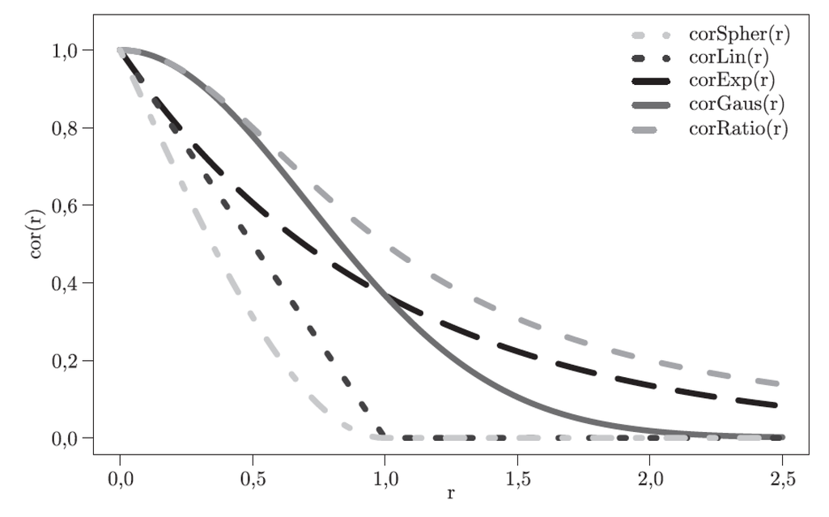

# 4. Pokrewieństwo

Wykorzystamy ponownie zbiór danych o myszach, aby omówić zagadnienie skorelowanych pomiarów.

Będziemy szukać zależności diety na parametry mięśnia u myszy.

```r
library(lme4)
library(PBImisc)
library(ggplot2)
library(coxme)
require(kinship2)

head(musculus)
```

```
##   id dadid momid sex sigma diet   k1   k2   E1    E2
## 1  1     0     0   1  4.01   D2 0.18 1.72 0.62 12.41
## 2  2     0     0   2  1.62   D2 0.24 2.07 0.10  7.81
## 3  3     0     0   2  3.53   D1 0.11 1.88 0.38  8.68
## 4  4     1     2   1  1.86   D2 0.17 2.08 0.37  9.54
## 5  5     1     2   1  4.41   D1 0.20 1.75 0.32 10.32
## 6  6     0     0   2  5.10   D1 0.06 1.13 0.61  7.62
```

Porównujemy dwie grupy, wydawać by się mogło, że to test dla dwóch grup.

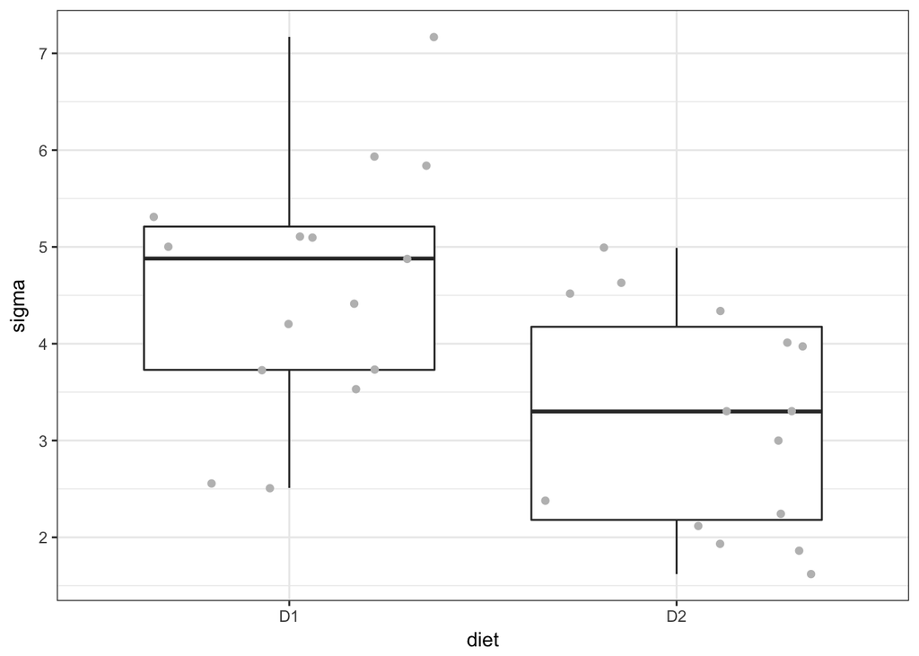

```r
ggplot(musculus, aes(diet, sigma)) +
  geom_boxplot() + geom_jitter(color="grey") + theme_bw()
```

```r
summary(lm(sigma~diet, data=musculus))
```

```
##
## Call:
## lm(formula = sigma ~ diet, data = musculus)
##
## Residuals:
##     Min      1Q  Median      3Q     Max
## -2.0907 -0.9482  0.0860  0.7860  2.5693
##
## Coefficients:
##             Estimate Std. Error t value Pr(>|t|)
## (Intercept)   4.6007     0.3117  14.759 9.78e-15 ***
## dietD2       -1.3867     0.4408  -3.146  0.00391 **
## ---
## Signif. codes:  0 '***' 0.001 '**' 0.01 '*' 0.05 '.' 0.1 ' ' 1
##
## Residual standard error: 1.207 on 28 degrees of freedom
## Multiple R-squared:  0.2611, Adjusted R-squared:  0.2347
## F-statistic: 9.894 on 1 and 28 DF,  p-value: 0.003907
```

Ale niestety to nie takie proste. Porównywane osobniki są spokrewnione a spokrewnienie powoduje określoną strukturę podobieństwa genetycznego.

Współczynnik pokrewieństwa to miara ilości materiału genetycznego współdzielonego przez dwa osobniki. Technicznie rzecz biorąc, mierzy on prawdopodobieństwa że dwa losowo wybrane allele są identyczne przez pochodzenie (IBD).

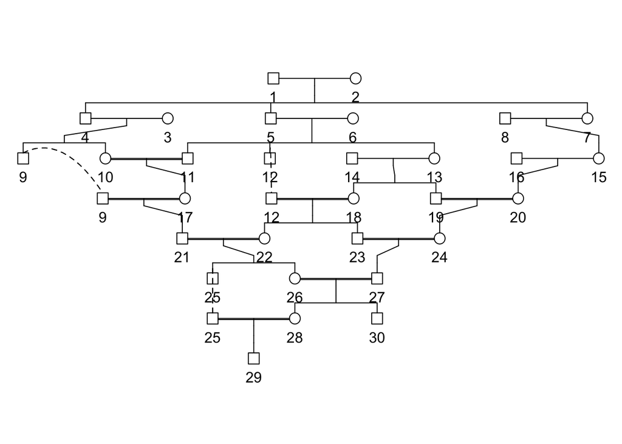

```r
gped <- with(musculus, pedigree(id, dadid, momid, sex=sex))
plot(gped)
```

```r
kmat <- kinship(gped)
kmat[1:5,1:15]
```

```
##      1    2   3    4    5 6    7 8     9    10    11    12    13 14    15
## 1 0.50 0.00 0.0 0.25 0.25 0 0.25 0 0.125 0.125 0.125 0.125 0.125  0 0.125
## 2 0.00 0.50 0.0 0.25 0.25 0 0.25 0 0.125 0.125 0.125 0.125 0.125  0 0.125
## 3 0.00 0.00 0.5 0.00 0.00 0 0.00 0 0.250 0.250 0.000 0.000 0.000  0 0.000
## 4 0.25 0.25 0.0 0.50 0.25 0 0.25 0 0.250 0.250 0.125 0.125 0.125  0 0.125
## 5 0.25 0.25 0.0 0.25 0.50 0 0.25 0 0.125 0.125 0.250 0.250 0.250  0 0.125
```

Taki poligenetyczny efekt można włączyć do modelu. Można to zrobić na kilka sposobów.

```r
mfit <- lmekin(sigma~diet + (1|id), data=musculus, varlist=kmat*2)
mfit
```

```
## Linear mixed-effects kinship model fit by maximum likelihood
##   Data: musculus
##   Log-likelihood = -38.14709
##   n= 30
##
##
## Model:  sigma ~ diet + (1 | id)
## Fixed coefficients
##                 Value Std Error     z       p
## (Intercept)  4.570159 0.4472368 10.22 0.0e+00
## dietD2      -1.465628 0.2414820 -6.07 1.3e-09
##
## Random effects
##  Group Variable Std Dev  Variance
##  id    Vmat.1   1.118715 1.251524
## Residual error= 0.1339208
```

```r
# Let's compare with
summary(lm(sigma~diet, data=musculus))
```

```
##
## Call:
## lm(formula = sigma ~ diet, data = musculus)
##
## Residuals:
##     Min      1Q  Median      3Q     Max
## -2.0907 -0.9482  0.0860  0.7860  2.5693
##
## Coefficients:
##             Estimate Std. Error t value Pr(>|t|)
## (Intercept)   4.6007     0.3117  14.759 9.78e-15 ***
## dietD2       -1.3867     0.4408  -3.146  0.00391 **
## ---
## Signif. codes:  0 '***' 0.001 '**' 0.01 '*' 0.05 '.' 0.1 ' ' 1
##
## Residual standard error: 1.207 on 28 degrees of freedom
## Multiple R-squared:  0.2611, Adjusted R-squared:  0.2347
## F-statistic: 9.894 on 1 and 28 DF,  p-value: 0.003907
```

Dzięki takiemu podejściu do modelowania można oszacować udział zmienności związanej z efektem poligenetycznym.

```r
(sigmaa <- mfit$vcoef$id)
```

```
##   Vmat.1
## 1.251524
```

```r
(sigma0 <- mfit$sigma^2)
```

```
## [1] 0.01793478
```

```r
sigmaa/(sigmaa+sigma0)
```

```
##    Vmat.1
## 0.9858721
```